# Simulating Experiments: **Overview & Review**

This lesson aims to conceptually connect the content from the two previous lessons: "Random Variables" and "Hypothesis Testing". In order to understand how Random Variables are connected to Hypothesis Testing, it is easy (and fun!) to simulate experiments.

**Goals**:

- To learn how to simulate a variety of experiments
- To learn what hypothesis testing's p values mean

## Lesson 07 Review

In Lesson 07 we learned that a large number of random values can be drawn from the Normal distribution like this:

```python
import numpy as np
from scipy import stats
from matplotlib import pyplot as plt
```

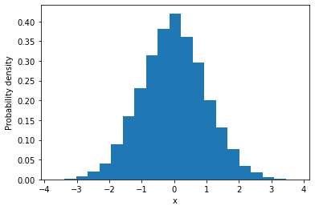

```python
np.random.seed(0)
x = np.random.randn(10000)

plt.figure()
ax = plt.axes()
ax.hist(x, density=True, bins=21)
ax.set_xlabel('x')
ax.set_ylabel('Probability density')
plt.show()
```

We also learned that probabilities associated with this distribution, like $P( x > 1.5 )$, can be computed numerically like this:

```python
p = ( x > 1.5 ).mean()

print( p )
```

```
0.0645
```

Finally, we learned that the same probability can be computed analytically like this:

```python
p = stats.norm.sf(1.5)

print( p )
```

```
0.06680720126885807
```

## Lesson 08 Review

In Lesson 08 we learned that:

- Hypothesis testing tests a null hypothesis ($H_0$)
- A null hypothesis is a specific experimental prediction, like: ($H_0: x = c$)
- A hypothesis test produces a p value
- $H_0$ is rejected when $p < \alpha$ $ \ \ \ \ $ (usually $\alpha=0.05$)

*How are all of these concepts related?*

The easiest way to answer this question is to simulate experiments. The next notebook demonstrates how to simulate a single, simple experiment. The following notebook demonstrates how to repeat the process for a large number of experiments. The last notebook in this lesson then connects the simulation concepts in this lesson to the probability and hypothesies testing concepts from the previous two lessons.